```python
import numpy as np
import pandas as pd
from numpy import linalg as LA
import math
from scipy.sparse import csr_matrix, diags
from scipy.sparse.linalg import spsolve, spsolve_triangular

# Timer
from timeit import default_timer as timer
# Visualisation libraries

## matplotlib
import matplotlib.pyplot as plt
from pylab import rcParams
plt.style.use('seaborn-whitegrid')
plt.rcParams['figure.figsize'] = 14, 8
plt.rcParams['axes.labelsize'] = 14
plt.rcParams['xtick.labelsize'] = 12
plt.rcParams['ytick.labelsize'] = 12
plt.rcParams['text.color'] = 'k'
%matplotlib inline

## plotly
from plotly.offline import init_notebook_mode, iplot
import plotly.graph_objs as go
import plotly.offline as py
from plotly.subplots import make_subplots
# Graphics in retina format
%config InlineBackend.figure_format = 'retina'

import warnings
warnings.filterwarnings('ignore')
```

# The Wave Equation in Time Domain

The wave equation in time domain can be stated as follows, \begin{equation} \frac{\partial^2 u}{\partial t^2}=c^2 \nabla^2 u+f,\qquad x\in \Omega \subset \mathbb{R}^d,~t\in(T_1,T_2] \end{equation} where $\Delta$ is *the Laplacian*, $f$ is a *forcing function* (for example our source) and $c$ is *the wave velocity* at which the time and spatially varying wave $u$ propagates.

## Second-Order Finite-Difference Methods for the One Dimensional Wave Equation in Time Domain

A one-dimensional form of the wave equation presented can be found as follows, \begin{align*} \begin{cases} \dfrac{\partial^2 u}{\partial t^2} = c^2(x) \dfrac{\partial^2 u}{\partial x^2}+f(x,t),&(x,t)\in (a,b)\times(T_1,T_2],\\ u(x,T_1)=g(x),&x\in [a,b],\\ \dfrac{\partial }{\partial t}u(x,T_1) = h(x),&x\in [a,b],\\ u(a,t) = f_a(t),&t \in[T_1,T_2],\\ u(b,t) = f_b(t),&t \in[T_1,T_2]. \end{cases} \qquad \qquad (1) \end{align*}

The following notations are introduced to generate an algorithm for the problem,

- $h=\Delta x=\frac{b-a}{N_x}$ and $\tau=\Delta t=\frac{T_2-T_1}{N_t}$ where $M$ and $N$ are positive integers,
- $u_{i}^{n}=u(ih,n\tau)$, $f_{i}^{n}=f(ih,n\tau)$ for $0\leq i \leq N_x$ and $0\leq n \leq N_t$,
- $c_{i}=c(ih)$ for $0\leq i \leq N_x$ and $\lambda=\frac{\tau}{h}$.

Moreover, a general form of implicit Finite-Difference scheme of the problem (1) can be written as follows, $$ \frac{1}{\tau^2}\delta_t^2 u_{i}^{n}= \frac{1}{h^2}c_{i}^2\left(\alpha \delta_x^2 u_{i}^{n+1} +\beta \delta_x^2 u_{i}^{n} +\gamma \delta_x^2 u_{i}^{n-1}\right)+f_{i}^{n}, $$ where $\delta^2$ is the central difference operator and $\alpha,~\beta$ and $\gamma$ are constants such that $\alpha+\beta+\gamma=1$. It follows that \begin{align*} u_{i}^{n+1}-2u_{i}^{n}+u_{i}^{n-1} &= \alpha c_{i}^2 \lambda^2\left( u_{i+1}^{n+1}-2u_{i}^{n+1}+u_{i-1}^{n+1}\right) +\beta c_{i}^2 \lambda^2 \left( u_{i+1}^{n} -2 u_{i}^{n}+ u_{i-1}^{n}\right) +\gamma c_{i}^2 \lambda^2 \left(u_{i+1}^{n-1}-2 u_{i}^{n-1}+u_{i-1}^{n-1}\right)+ \tau^2f_{i}^{n}. \end{align*}

This also can be simplified as follows, \begin{align*} -\alpha c_{i}^2 \lambda^2 \left(u_{i-1}^{n+1}+u_{i+1}^{n+1}\right)+\left(1 +2 \alpha c_{i}^2 \lambda^2 \right)u_{i}^{n+1}&=\beta c_{i}^2 \lambda^2 \left(u_{i-1}^{n}+u_{i+1}^{n} \right) +2\left(1 -\beta c_{i}^2 \lambda^2 \right)u_{i}^{n}+\gamma c_{i}^2 \lambda^2 \left(u_{i-1}^{n-1}+u_{i+1}^{n-1} \right) \notag\\ & -\left(1 +2 \gamma c_{i}^2 \lambda^2 \right)u_{i}^{n-1}+\tau^2f_{i}^{n}. \qquad \qquad (2) \end{align*}

The following matrices are introduced to write down a matrix form of the equation (2), $$ A=\begin{bmatrix} 1 +2 \alpha c_{1}^2 \lambda^2 & -\alpha c_{1}^2 \lambda^2 & 0 & \dots & \dots &0 \\ -\alpha c_{2}^2 \lambda^2 &1 +2 \alpha c_{2}^2 \lambda^2 & -\alpha c_{2}^2 \lambda^2 & 0 & \vdots &\vdots \\ 0 &-\alpha c_{3}^2 \lambda^2 &1 +2 \alpha c_{3}^2 \lambda^2 & -\alpha c_{3}^2 \lambda^2 &0 &\vdots \\ 0 &0 & \ddots & \ddots &\ddots &\vdots \\ \vdots &\vdots & -\alpha c_{M-3}^2 \lambda^2 & 1 +2 \alpha c_{M-3}^2 \lambda^2 &-\alpha c_{M-3}^2 \lambda^2 & 0 \\ \vdots &\vdots & 0 & -\alpha c_{N_x-2}^2 \lambda^2 & 1 +2 \alpha c_{N_x-2}^2 \lambda^2 &-\alpha c_{N_x-2}^2 \lambda^2 \\ 0 &0 & \dots & 0 & -\alpha c_{N_x-1}^2 \lambda^2 & 1 +2 \alpha c_{N_x-1}^2 \lambda^2 \end{bmatrix}, $$ $$ B=\begin{bmatrix} 2 -2 \beta c_{1}^2 \lambda^2 & \beta c_{1}^2 \lambda^2 & 0 & \dots & \dots &0 \\ \beta c_{2}^2 \lambda^2 &2 -2 \beta c_{2}^2 \lambda^2 & \beta c_{2}^2 \lambda^2 & 0 & \vdots &\vdots \\ 0 &\beta c_{3}^2 \lambda^2 &2 -2 \beta c_{3}^2 \lambda^2 & \beta c_{3}^2 \lambda^2 &0 &\vdots \\ 0 &0 & \ddots & \ddots &\ddots &\vdots \\ \vdots &\vdots & \beta c_{M-3}^2 \lambda^2 & 2 -2 \beta c_{M-3}^2 \lambda^2 &\beta c_{M-3}^2 \lambda^2 & 0 \\ \vdots &\vdots & 0 & \beta c_{N_x-2}^2 \lambda^2 & 2 -2 \beta c_{N_x-2}^2 \lambda^2 &\beta c_{N_x-2}^2 \lambda^2 \\ 0 &0 & \dots & 0 & \beta c_{N_x-1}^2 \lambda^2 & 2 -2 \beta c_{N_x-1}^2 \lambda^2 \end{bmatrix}, $$ $$ C=\begin{bmatrix} -1-2 \gamma c_{1}^2 \lambda^2 & \gamma c_{1}^2 \lambda^2 & 0 & \dots & \dots &0 \\ \gamma c_{2}^2 \lambda^2 &-1-2 \gamma c_{2}^2 \lambda^2 & \gamma c_{2}^2 \lambda^2 & 0 & \vdots &\vdots \\ 0 &\gamma c_{3}^2 \lambda^2 &-1-2 \gamma c_{3}^2 \lambda^2 & \gamma c_{3}^2 \lambda^2 &0 &\vdots \\ 0 &0 & \ddots & \ddots &\ddots &\vdots \\ \vdots &\vdots & \gamma c_{M-3}^2 \lambda^2 & -1-2 \gamma c_{M-3}^2 \lambda^2 &\gamma c_{M-3}^2 \lambda^2 & 0 \\ \vdots &\vdots & 0 & \gamma c_{N_x-2}^2 \lambda^2 & -1-2 \gamma c_{N_x-2}^2 \lambda^2 &\gamma c_{N_x-2}^2 \lambda^2 \\ 0 &0 & \dots & 0 & \gamma c_{N_x-1}^2 \lambda^2 & -1-2 \gamma c_{N_x-1}^2 \lambda^2 \end{bmatrix}, $$ and also $$ \mathbf{u}^n=\begin{bmatrix} u_{1}^{n} \\ u_{2}^{n}\\ \vdots\\ u_{N_x-2}^{n}\\ u_{N_x-1}^{n} \end{bmatrix},~ \mathbf{b}^n= \begin{bmatrix} c_{1}^2 \lambda^2 \left(\alpha u_{0}^{n+1}+\beta u_{0}^{n}+\gamma u_{0}^{n-1}\right) \\ 0\\ \vdots\\ 0\\ c_{N_x-1}^2 \lambda^2 \left(\alpha u_{N_x}^{n+1}+\beta u_{N_x}^{n}+\gamma u_{N_x}^{n-1}\right) \end{bmatrix},~ \mathbf{F}^n=\tau^2 \begin{bmatrix} f_{1}^{n}\\ f_{2}^{n}\\ \vdots\\ f_{N_x-2}^{n}\\ f_{N_x-1}^{n} \end{bmatrix}. $$ Therefore, the following matrix form of equation (2) can be stated based as follows, $$ A \mathbf{u}^{n+1}=B \mathbf{u}^{n}+C \mathbf{u}^{n-1}+\mathbf{b}^n+\mathbf{F}^n, $$ which implies $$ \mathbf{u}^{n+1}=A^{-1}\left(B \mathbf{u}^{n}+C \mathbf{u}^{n-1}+\mathbf{b}^n+ \mathbf{F}^n\right). $$

Finite differnce method for the wave equation in time usually require computing the solution on the first two time steps. The solution on the second time step, $u(x,T_1+k)$, can be approximated as follows by means of Taylor series, \begin{align*} u(x,T_1+\tau)&=u(x,T_1)+u_t(x,T_1)\tau+\frac{1}{2} u_{tt}(x,T_1)\tau^2+\frac{1}{6} u_{ttt}(x,T_1)\tau^3 +\frac{1}{24} u_{tttt}(x,T_1)\tau^4 +\mathcal{O}(\tau^5) \notag \\ & =g(x)+s(x)\tau+\frac{1}{2} u_{tt}(x,T_1)\tau^2+\frac{1}{6} u_{ttt}(x,T_1)\tau^3+\frac{1}{24} u_{tttt}(x,T_1)\tau^4+\mathcal{O}(\tau^5) \notag \\ & =g(x)+s(x)\tau+\frac{1}{2}[c^2(x) \Delta g(x)+f(x,T_1)]\tau^2 +\frac{1}{6} [c^2(x) \Delta s(x)+f_t(x,T_1)]\tau^3 \notag\\ & +\frac{1}{24}[c^2(x) \Delta [c^2(x) \Delta g(x)+f(x,T_1)] +f_{tt}(x,T_1)]\tau^4 +\mathcal{O}(\tau^5). \end{align*}

### Explicit Scheme

First, consider $\alpha=\gamma=0$ and $\beta=1$ in the equation (2) to get the **explicit** method.

### Implicit Scheme

Similarly, consider $\alpha=\gamma=\dfrac{1}{4}$ and $\beta=\dfrac{1}{2}$ in the equation (2) to the obtain **implicit** method.

For Stability and convergence analyses, see this [file](https://hatefdastour.github.io/notes/FDTD/Stability_and_Convergence_FDTD_2nd_1D.pdf).

**Example**

Consider the following problem, \begin{align*} \frac{\partial^2 u}{\partial t^2} &= \mathrm{e}^{-x} \frac{\partial^2 u}{\partial x^2}+{\mathrm{e}}^{t+x}-{\mathrm{e}}^t ,&(x,t)\in (0,1)\times(0,1],\\ u(x,0)&=\mathrm{e}^{x},&x\in [0,1],\\ \frac{\partial }{\partial t}u(x,0) &= \mathrm{e}^{x},&x\in [0,1],\\ u(0,t) &= \mathrm{e}^{t} &t \in[0,1],\\ u(1,t) &= \mathrm{e}^{t+1},&t \in[0,1]. \end{align*} The exact solution corresponding to the problem can be found as follows, $$ u(x,t)=\mathrm{e}^{x+t} $$

### The Explicit Scheme

```python
def Figs(U_exact, U_Comp, Scheme, data, y_range = None):
    fig = go.Figure()
    # [a,b] and [T1,T2]
    a = 0.0
    b = 1.0
    T1 = 0.0
    T2 = 1.0
    x = np.linspace(a, b, U_exact.shape[0])
    fig.add_trace(go.Scatter(x = x, y = U_Comp, mode='lines', name='Approximated'))
    fig.add_trace(go.Scatter(x = x, y = U_exact, mode='lines', name='Exact'))
    fig['layout']['xaxis'].update(range=[x[0], x[-1]])
    if y_range != None :
        fig['layout']['yaxis'].update(range=y_range)
    fig.update_xaxes(showline=True, linewidth=1, linecolor='Lightgray', mirror=True,
                    showgrid=True, gridwidth=1, gridcolor='Lightgray',
                    title_text = '$x$')
    fig.update_yaxes(showline=True, linewidth=1, linecolor='Lightgray', mirror=True,
                    showgrid=True, gridwidth=1, gridcolor='Lightgray',
                    title_text = '$u(x,1)$')
    fig.update_xaxes(zeroline=True, zerolinewidth=1, zerolinecolor='Lightgray')
    fig.update_yaxes(zeroline=True, zerolinewidth=1, zerolinecolor='Lightgray')
    fig.update_layout(legend_orientation='v', plot_bgcolor= 'white', height= 600, width= 670)
    fig.update_traces(marker_line_color= 'Black', marker_line_width=0.5, opacity=1)
    fig.update_layout(title={'text':  r'%s Approximation with Nx = %i and Nt = %i' %
                             (Scheme,data.Nx.values[-1], data.Nt.values[-1]),
                             'x':0.46, 'y':0.88, 'xanchor': 'center', 'yanchor': 'top'},
                      font=dict(size=10))
    fig.show()

def Example01_ExSolver1D(Nx,Nt):
    # N = the number of mesh points for space
    # Nt = the number of mesh points for time
    # [a,b] and [T1,T2]
    a = 0.0
    b = 1.0
    T1 = 0.0
    T2 = 1.0
    # Functions
    C2 =lambda x: np.exp(-x)
    g=lambda x: np.exp(x)
    h=lambda x: np.exp(x)
    fa=lambda t: np.exp(t)
    fb=lambda t: np.exp(t+1)
    f=lambda x,t: np.exp(t + x) - np.exp(t)
    Ue=lambda x,t: np.exp(x+t)
    # Additional functions
    gxx=lambda x: np.exp(x);
    gxxxx=lambda x: np.exp(x);
    hxx=lambda x: np.exp(x);
    ft=lambda x,t: np.exp(t + x) - np.exp(t);
    ftt=lambda x,t: np.exp(t + x) - np.exp(t);
    # dx, dt and lambda^2
    dx =(b-a)/Nx
    dt =(T2-T1)/Nt
    l2=(dt/dx)**2
    # discretizing [a,b] and [T1,T2]
    xx=np.linspace(a, b, Nx+1)
    tt=np.linspace(T1, T2, Nt+1)
    # dicretizing c^2(x)
    CC=C2(xx)
    # u initial time value
    u0 = g(xx);
    u=np.zeros(Nx+1, dtype=float)
    u1=np.zeros(Nx+1, dtype=float)
    # Computing the solution at the first time step
    GG= g(xx)+h(xx)*dt+0.5*(C2(xx)*gxx(xx)+f(xx,T1))*(dt**2)+\
    (1/6)*(C2(xx)*hxx(xx)+ft(xx,T1))*(dt**3)+(1/24)*(C2(xx)*gxxxx(xx)+ftt(xx,T1))*(dt**4)
    u1[1:Nx]=GG[1:Nx]
    u1[0]=fa(tt[1])
    u1[Nx]=fb(tt[1])
    mid=list(range(1,Nx))
    midp=[i+1 for i in mid]
    midm=[i-1 for i in mid]
    # for loop
    for n in range(1,Nt):
        u=np.zeros(Nx+1, dtype=float)
        u[mid]=l2*CC[mid]*(u1[midp]-2*u1[mid]+u1[midm])+2*u1[mid]-u0[mid]+(dt**2)*f(xx[mid],tt[n])
        u[0]=fa(tt[n+1])
        u[Nx]=fb(tt[n+1])
        u0=u1
        u1=u
    # end of the loop
    # Norm
    U_Comp = u
    U_exact = Ue(xx,tt[-1])
    Norm=LA.norm(U_Comp - U_exact, np.inf)
    return Norm, U_exact, U_Comp
```

```python
it=4
Norm=np.zeros(it, dtype=float)
Nx0=10;
Nt0=200;
Nx=np.asarray([Nx0*2**n for n in range(0,it)])
Nt=np.asarray([Nt0 for n in range(0,it)])
Ratio=np.zeros(it, dtype=float)
LOG=np.zeros(it, dtype=float)
CPU_Time=np.zeros(it, dtype=float)
# iteration
for n in range(it):
    if n != (it-1):
        start = timer()
        Norm[n],_,_ =Example01_ExSolver1D(Nx[n],Nt[n])
        CPU_Time[n] = timer() - start
    else:
        start = timer()
        Norm[n], U_exact, U_Comp =Example01_ExSolver1D(Nx[n],Nt[n])
        CPU_Time[n] = timer() - start
    if (n>0):
        Ratio[n]=Norm[n-1]/Norm[n]
        LOG[n]=math.log(Ratio[n],2)

data = pd.DataFrame({'Nx': Nx+1, 'Nt': Nt+1, 'Norm': Norm, 'Ratio': Ratio, 'Log2': LOG, 'CPU Time': CPU_Time})
del it, Norm, Nx0, Nt0, Nx, Nt, Ratio, LOG, CPU_Time, n, start
display(data.style.format({'Norm': "{:.4e}"}))
Figs(U_exact, U_Comp, Scheme = 'Explicit Scheme', data = data)
```

|  | Nx | Nt | Norm | Ratio | Log2 | CPU Time |
| --- | --- | --- | --- | --- | --- | --- |
| 0 | 11 | 201 | 4.7653e-04 | 0.000000 | 0.000000 | 0.009033 |
| 1 | 21 | 201 | 1.1857e-04 | 4.018871 | 2.006790 | 0.009048 |
| 2 | 41 | 201 | 2.8054e-05 | 4.226541 | 2.079477 | 0.010351 |
| 3 | 81 | 201 | 5.4085e-06 | 5.187090 | 2.374925 | 0.013959 |

[interactive chart not shown]

```python
it=4
Norm=np.zeros(it, dtype=float)
Nx0=10;
Nt0=20;
Nx=np.asarray([Nx0*2**n for n in range(0,it)])
Nt=np.asarray([Nt0*2**n for n in range(0,it)])
Ratio=np.zeros(it, dtype=float)
LOG=np.zeros(it, dtype=float)
CPU_Time=np.zeros(it, dtype=float)
# iteration
for n in range(it):
    if n != (it-1):
        start = timer()
        Norm[n],_,_ =Example01_ExSolver1D(Nx[n],Nt[n])
        CPU_Time[n] = timer() - start
    else:
        start = timer()
        Norm[n], U_exact, U_Comp =Example01_ExSolver1D(Nx[n],Nt[n])
        CPU_Time[n] = timer() - start
    if (n>0):
        Ratio[n]=Norm[n-1]/Norm[n]
        LOG[n]=math.log(Ratio[n],2)

data = pd.DataFrame({'Nx': Nx+1, 'Nt': Nt+1, 'Norm': Norm, 'Ratio': Ratio, 'Log2': LOG, 'CPU Time': CPU_Time})
del it, Norm, Nx0, Nt0, Nx, Nt, Ratio, LOG, CPU_Time, n, start
display(data.style.format({'Norm': "{:.4e}"}))
Figs(U_exact, U_Comp, Scheme = 'Explicit Scheme', data = data)
```

|  | Nx | Nt | Norm | Ratio | Log2 | CPU Time |
| --- | --- | --- | --- | --- | --- | --- |
| 0 | 11 | 21 | 2.6548e-04 | 0.000000 | 0.000000 | 0.001403 |
| 1 | 21 | 41 | 6.6948e-05 | 3.965520 | 1.987510 | 0.002410 |
| 2 | 41 | 81 | 1.6789e-05 | 3.987502 | 1.995485 | 0.004779 |
| 3 | 81 | 161 | 4.2064e-06 | 3.991334 | 1.996871 | 0.010814 |

[interactive chart not shown]

What stands out from the tables is that the order of the method is 2 (space and time). To test the stability condition, we can try the following experiment.

```python
it=4
Norm=np.zeros(it, dtype=float)
Nx0=10;
Nt0=8;
Nx=np.asarray([Nx0*2**n for n in range(0,it)])
Nt=np.asarray([Nt0*2**n for n in range(0,it)])
Ratio=np.zeros(it, dtype=float)
LOG=np.zeros(it, dtype=float)
CPU_Time=np.zeros(it, dtype=float)
# iteration
for n in range(it):
    start = timer()
    Norm[n],_,_ =Example01_ExSolver1D(Nx[n],Nt[n])
    CPU_Time[n] = timer() - start
    if (n>0):
        Ratio[n]=Norm[n-1]/Norm[n]
        LOG[n]=math.log(Ratio[n],2)

data = pd.DataFrame({'Nx': Nx+1, 'Nt': Nt+1, 'Norm': Norm, 'Ratio': Ratio, 'Log2': LOG, 'CPU Time': CPU_Time})
del it, Norm, Nx0, Nt0, Nx, Nt, Ratio, LOG, CPU_Time, n, start
display(data.style.format({'Norm': "{:.4e}"}))
```

|  | Nx | Nt | Norm | Ratio | Log2 | CPU Time |
| --- | --- | --- | --- | --- | --- | --- |
| 0 | 11 | 9 | 8.4073e-04 | 0.000000 | 0.000000 | 0.000787 |
| 1 | 21 | 17 | 3.3127e-02 | 0.025379 | -5.300234 | 0.001097 |
| 2 | 41 | 33 | 1.3026e+06 | 0.000000 | -25.228801 | 0.002398 |
| 3 | 81 | 65 | 1.5785e+23 | 0.000000 | -56.749932 | 0.005285 |

The table highlights that the stability criteria were violated.

### The Implicit scheme

```python
def Example01_ImSolver1D(Nx,Nt):
    # Nx = the number of mesh points for space
    # Nt = the number of mesh points for time
    # alpha, beta and gamma
    alpha=1/4
    beta=1/2
    gamma=1/4
    # [a,b] and [T1,T2]
    a = 0.0
    b = 1.0
    T1 = 0.0
    T2 = 1.0
    # Functions
    C2 =lambda x: np.exp(-x)
    g=lambda x: np.exp(x)
    h=lambda x: np.exp(x)
    fa=lambda t: np.exp(t)
    fb=lambda t: np.exp(t+1)
    f=lambda x,t: np.exp(t + x) - np.exp(t)
    Ue=lambda x,t: np.exp(x+t)
    # Additional functions
    gxx=lambda x: np.exp(x);
    gxxxx=lambda x: np.exp(x);
    hxx=lambda x: np.exp(x);
    ft=lambda x,t: np.exp(t + x) - np.exp(t);
    ftt=lambda x,t: np.exp(t + x) - np.exp(t);
    # dx, dt and lambda^2
    dx =(b-a)/Nx
    dt =(T2-T1)/Nt
    l2=(dt/dx)**2
    # discretizing [a,b] and [T1,T2]
    xx=np.linspace(a, b, Nx+1)
    tt=np.linspace(T1, T2, Nt+1)
    # dicretizing c^2(x)
    CC=C2(xx)
    # u initial time value
    u0 = g(xx);
    u=np.zeros(Nx+1, dtype=float)
    u1=np.zeros(Nx+1, dtype=float)
    # Computing the solution at the first time step
    GG= g(xx)+h(xx)*dt+0.5*(C2(xx)*gxx(xx)+f(xx,T1))*(dt**2)+\
    (1/6)*(C2(xx)*hxx(xx)+ft(xx,T1))*(dt**3)+(1/24)*(C2(xx)*gxxxx(xx)+ftt(xx,T1))*(dt**4)
    u1[1:Nx]=GG[1:Nx]
    u1[0]=fa(tt[1])
    u1[Nx]=fb(tt[1])
    # indeces
    mid=list(range(1,Nx))
    sup=list(range(1,Nx-1))
    sub=list(range(2,Nx))
    # Matrix A
    A=diags([-alpha*CC[sub]*l2,1+2*alpha*CC[mid]*l2,-alpha*CC[sup]*l2], [-1,0,1])
    # Matrix B
    B=diags([beta*CC[sub]*l2,2-2*beta*CC[mid]*l2,beta*CC[sup]*l2], [-1,0,1])
    # Matrix C
    C=diags([gamma*CC[sub]*l2,-1-2*gamma*CC[mid]*l2,gamma*CC[sup]*l2], [-1,0,1])
    # Fa and Fb
    FA= fa(tt)
    FB= fb(tt)
    for n in range(1,Nt):
        u=np.zeros(Nx+1, dtype=float)
        bb=np.zeros(len(mid), dtype=float)
        bb[0]=CC[1]*l2*(alpha*FA[n+1]+beta*FA[n]+gamma*FA[n-1])
        bb[Nx-2]=CC[Nx-1]*l2*(alpha*FB[n+1]+beta*FB[n]+gamma*FB[n-1])
        u[mid]=spsolve(A,B*u1[mid]+C*u0[mid]+bb+(dt**2)*f(xx[mid],tt[n]))
        u[0]=fa(tt[n+1])
        u[Nx]=fb(tt[n+1])
        u0=u1
        u1=u
    # end of the loop
    # Norm
    U_Comp = u
    U_exact = Ue(xx,tt[-1])
    Norm=LA.norm(U_Comp - U_exact, np.inf)
    return Norm, U_exact, U_Comp
```

```python
it=4
Norm=np.zeros(it, dtype=float)
Nx0=10;
Nt0=200;
Nx=np.asarray([Nx0*2**n for n in range(0,it)])
Nt=np.asarray([Nt0 for n in range(0,it)])
Ratio=np.zeros(it, dtype=float)
LOG=np.zeros(it, dtype=float)
CPU_Time=np.zeros(it, dtype=float)
# iteration
for n in range(it):
    if n != (it-1):
        start = timer()
        Norm[n],_,_ =Example01_ImSolver1D(Nx[n],Nt[n])
        CPU_Time[n] = timer() - start
    else:
        start = timer()
        Norm[n], U_exact, U_Comp =Example01_ImSolver1D(Nx[n],Nt[n])
        CPU_Time[n] = timer() - start
    if (n>0):
        Ratio[n]=Norm[n-1]/Norm[n]
        LOG[n]=math.log(Ratio[n],2)

data = pd.DataFrame({'Nx': Nx+1, 'Nt': Nt+1, 'Norm': Norm, 'Ratio': Ratio, 'Log2': LOG, 'CPU Time': CPU_Time})
del it, Norm, Nx0, Nt0, Nx, Nt, Ratio, LOG, CPU_Time, n, start
display(data.style.format({'Norm': "{:.4e}"}))
Figs(U_exact, U_Comp, Scheme = 'Explicit Scheme', data = data)
```

|  | Nx | Nt | Norm | Ratio | Log2 | CPU Time |
| --- | --- | --- | --- | --- | --- | --- |
| 0 | 11 | 201 | 4.8011e-04 | 0.000000 | 0.000000 | 0.042761 |
| 1 | 21 | 201 | 1.2219e-04 | 3.929173 | 1.974226 | 0.043279 |
| 2 | 41 | 201 | 3.1679e-05 | 3.857149 | 1.947535 | 0.045077 |
| 3 | 81 | 201 | 9.0324e-06 | 3.507299 | 1.810361 | 0.050744 |

[interactive chart not shown]

```python
it=4
Norm=np.zeros(it, dtype=float)
Nx0=200;
Nt0=10;
Nx=np.asarray([Nx0 for n in range(0,it)])
Nt=np.asarray([Nt0*2**n for n in range(0,it)])
Ratio=np.zeros(it, dtype=float)
LOG=np.zeros(it, dtype=float)
CPU_Time=np.zeros(it, dtype=float)
# iteration
for n in range(it):
    if n != (it-1):
        start = timer()
        Norm[n],_,_ =Example01_ImSolver1D(Nx[n],Nt[n])
        CPU_Time[n] = timer() - start
    else:
        start = timer()
        Norm[n], U_exact, U_Comp =Example01_ImSolver1D(Nx[n],Nt[n])
        CPU_Time[n] = timer() - start
    if (n>0):
        Ratio[n]=Norm[n-1]/Norm[n]
        LOG[n]=math.log(Ratio[n],2)

data = pd.DataFrame({'Nx': Nx+1, 'Nt': Nt+1, 'Norm': Norm, 'Ratio': Ratio, 'Log2': LOG, 'CPU Time': CPU_Time})
del it, Norm, Nx0, Nt0, Nx, Nt, Ratio, LOG, CPU_Time, n, start
display(data.style.format({'Norm': "{:.4e}"}))
Figs(U_exact, U_Comp, Scheme = 'Explicit Scheme', data = data)
```

|  | Nx | Nt | Norm | Ratio | Log2 | CPU Time |
| --- | --- | --- | --- | --- | --- | --- |
| 0 | 201 | 11 | 5.8221e-04 | 0.000000 | 0.000000 | 0.004496 |
| 1 | 201 | 21 | 1.4861e-04 | 3.917749 | 1.970025 | 0.006445 |
| 2 | 201 | 41 | 3.8270e-05 | 3.883177 | 1.957238 | 0.012610 |
| 3 | 201 | 81 | 1.0496e-05 | 3.646092 | 1.866351 | 0.024888 |

[interactive chart not shown]

### Convergence Rate

For a fixed $N_t$, we have

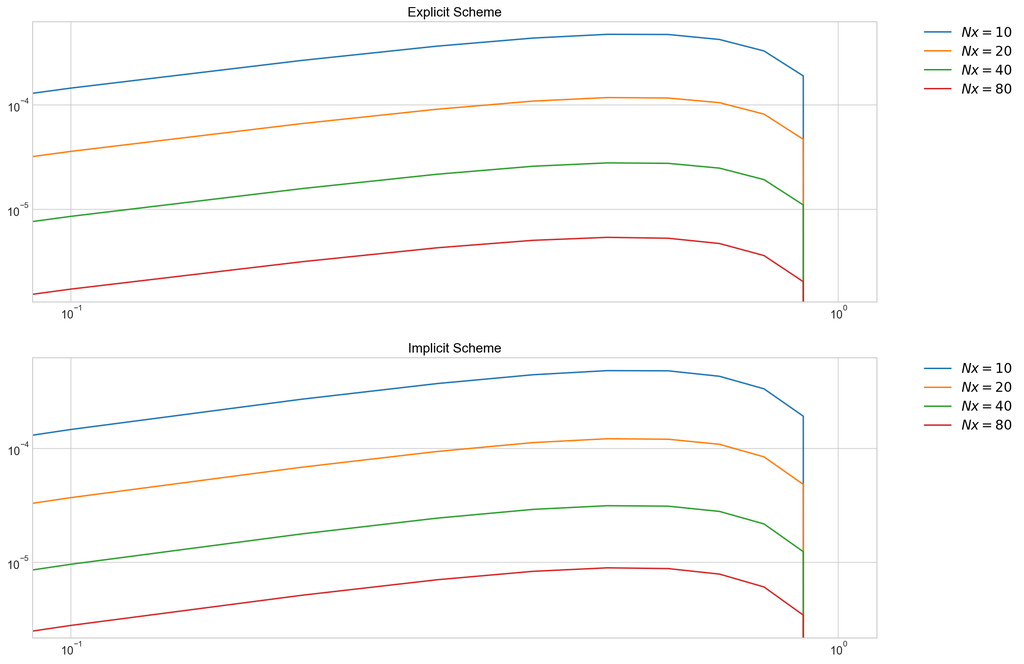

```python
it=4
Norm=np.zeros(it, dtype=float)
Nx0=10
Nt0=200
Nx=np.asarray([Nx0*2**n for n in range(0,it)])
Nt=np.asarray([Nt0 for n in range(0,it)])
#
Exact=np.zeros((it,Nx0+1), dtype=float)
Explicit_Scheme=np.zeros((it,Nx0+1), dtype=float)
Implicit_Scheme=np.zeros((it,Nx0+1), dtype=float)

#
for n in range(it):
    _,U_exact, U_Comp = Example01_ExSolver1D(Nx[n],Nt[n])
    Exact[n,:] = U_exact[0:(Nx[n]+1):(2**n)]
    Explicit_Scheme[n,:]=U_Comp[0:(Nx[n]+1):(2**n)]
    del U_exact, U_Comp
    _,_,U_Comp =Example01_ImSolver1D(Nx[n],Nt[n])
    Implicit_Scheme[n,:]=U_Comp[0:(Nx[n]+1):(2**n)]
    del U_Comp

fig, ax = plt.subplots(nrows=2, ncols=1, figsize=(16, 12))
for n in range(it):
    tag= "$Nx = %d$" % (Nx[n])
    _ = ax[0].loglog(np.linspace(0, 1, Nx0+1), np.abs(Exact[n,:]-Explicit_Scheme[n,:]),label=tag)
    _ = ax[0].legend(bbox_to_anchor=(1.05, 1), loc='upper left', borderaxespad=0., fontsize = 14)
    _ = ax[0].set_title('Explicit Scheme', fontsize = 14)
    _ = ax[1].loglog(np.linspace(0, 1, Nx0+1), np.abs(Exact[n,:]-Implicit_Scheme[n,:]),label=tag)
    _ = ax[1].legend(bbox_to_anchor=(1.05, 1), loc='upper left', borderaxespad=0., fontsize = 14)
    _ = ax[1].set_title('Implicit Scheme', fontsize = 14)
```